# Twitter followers

Emily Darling

December 25, 2016

## Twitter followers analysis

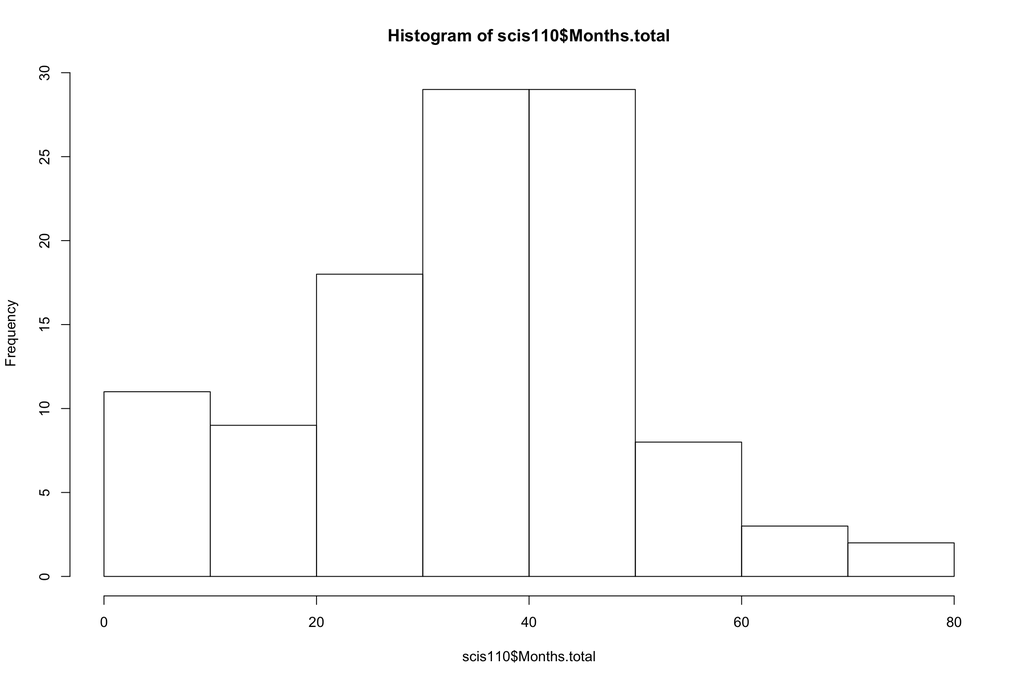

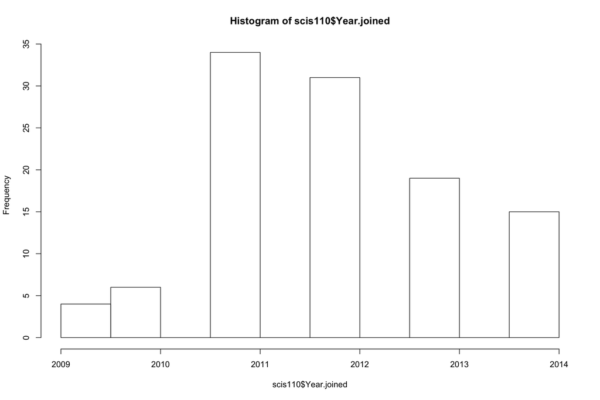

Followers have been classified into several major ‘types’ of followers using coded keywords and combinations of keywords. The accuracy of classification was checked by hand, and resulted in ~89% correct classification (~11% misclassification rate).

## Preliminary plots

NUVI provided us with a reach of each follower (along with their bio). Here, for each academic Twitter handle, I’ve summed their total reach across each academic’s followers. Not surprisingly, reach increases exponentially with the number of followers (note the log10 x-axis). Maybe we could do a GAM or breakpoint analysis to look if there’s a threshold here for when your total reach starts to increase?

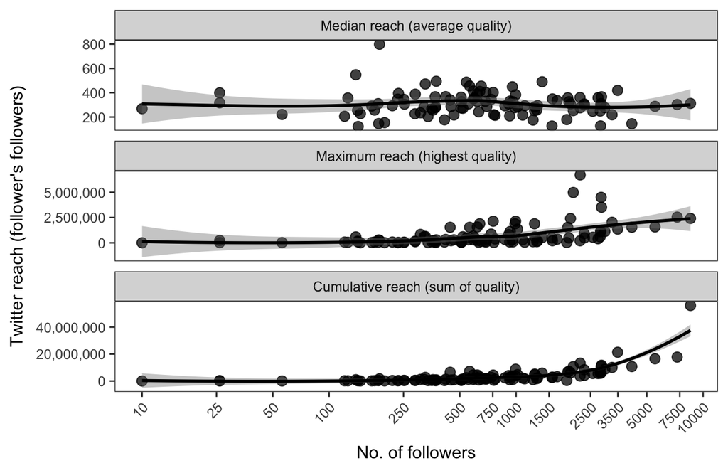

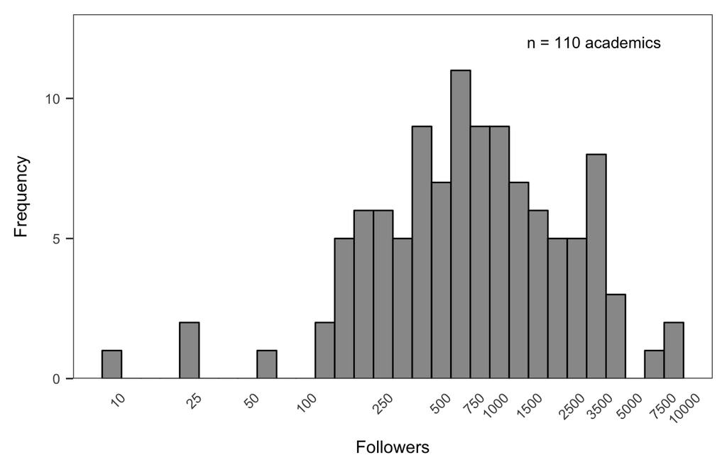

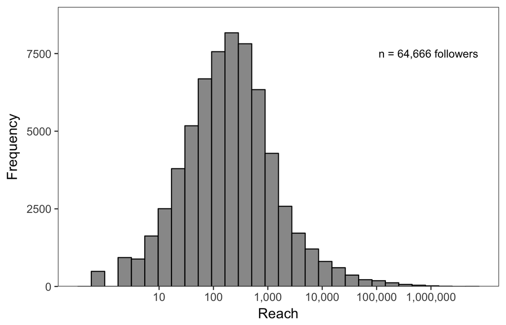

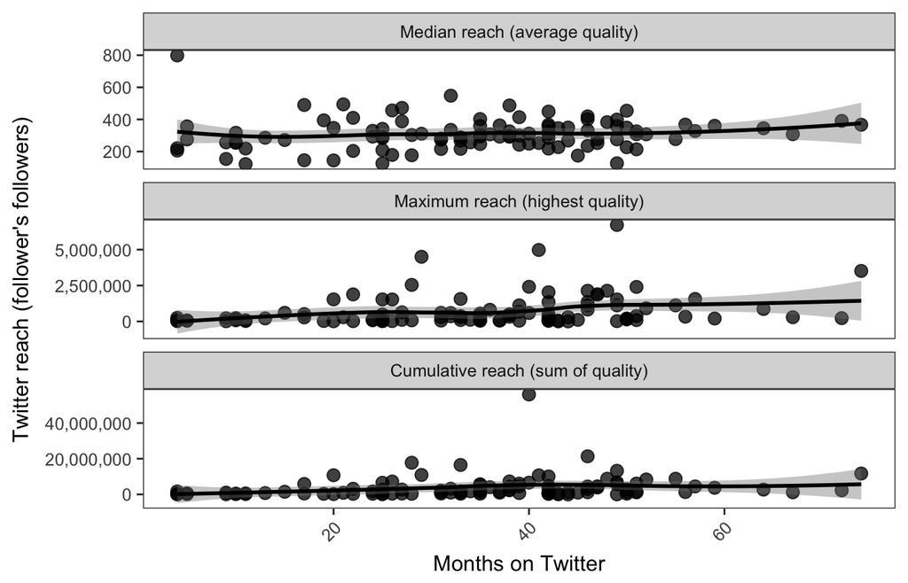

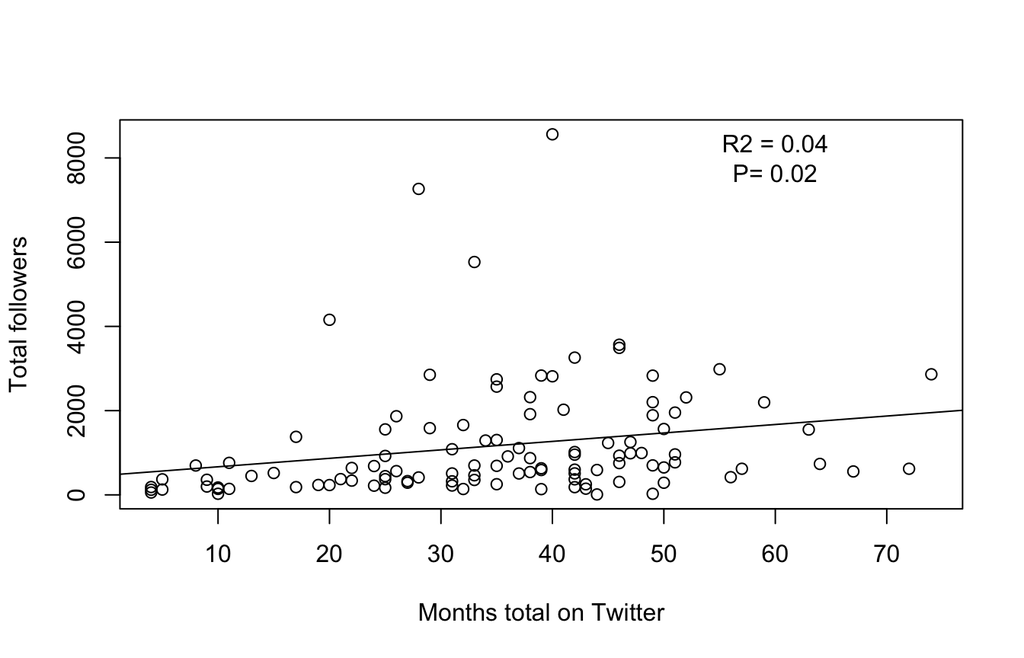

[figure not shown]

Next, I’ve calculated the average reach for the followers classified to each group.

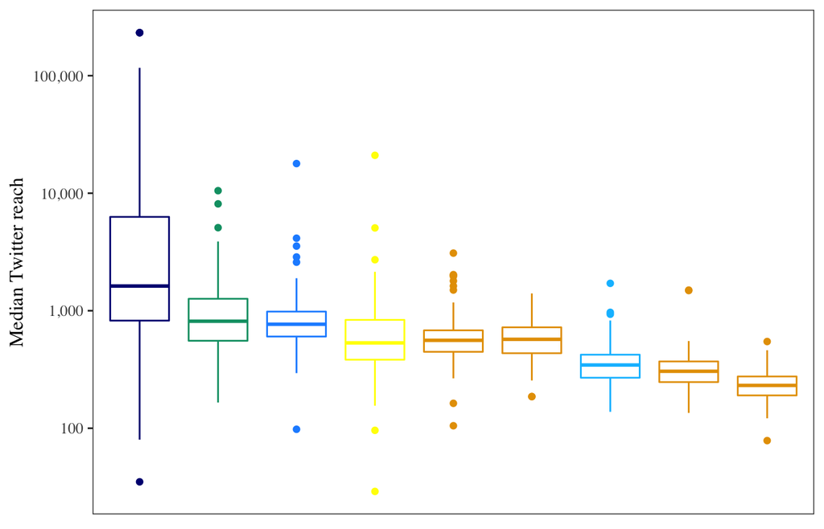

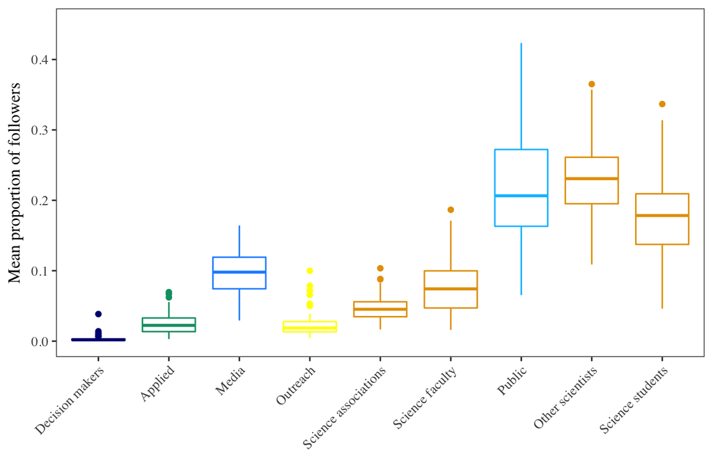

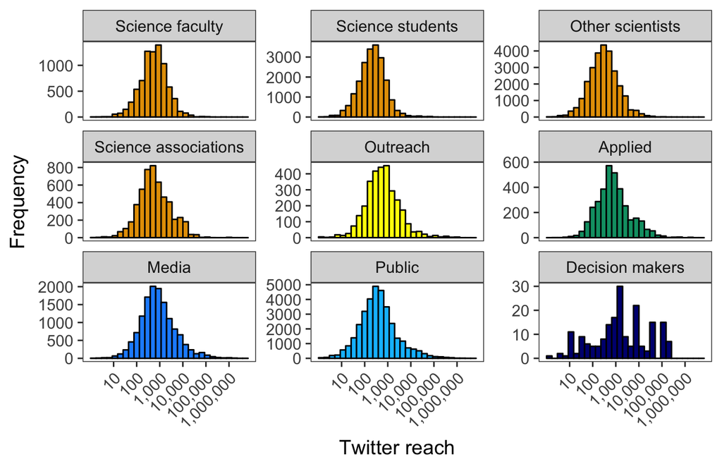

We can then look at how the number of followers predicts which groups you accumulate (if we consider # of followers as a space-for-time comparison).

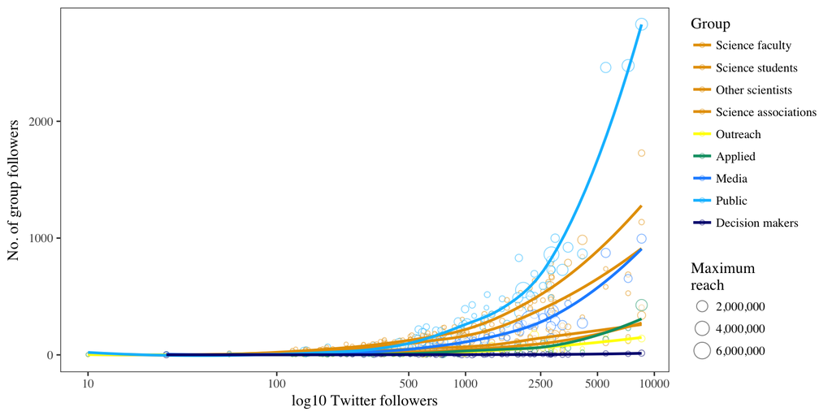

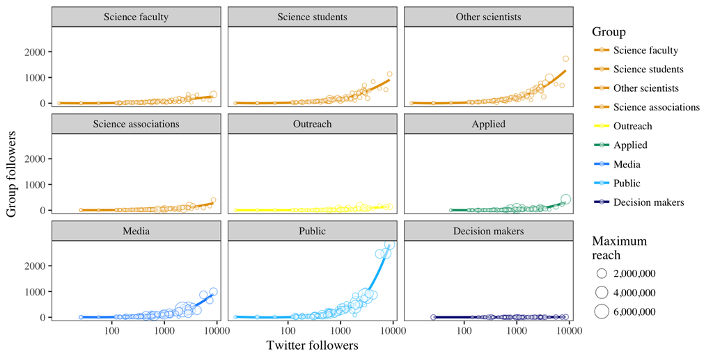

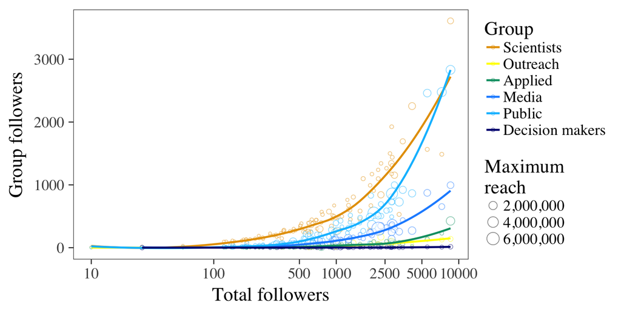

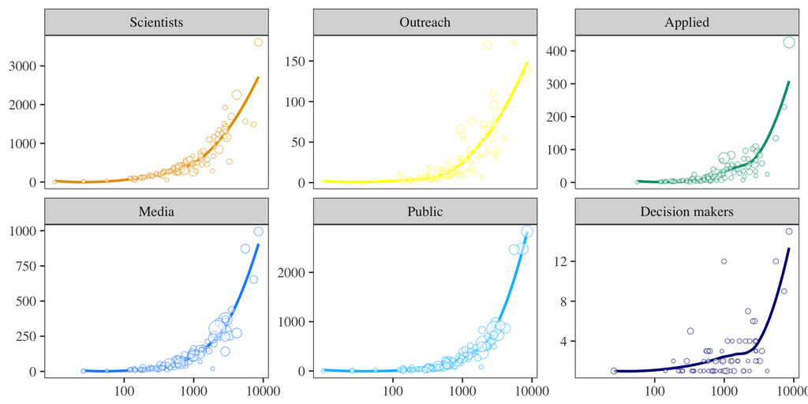

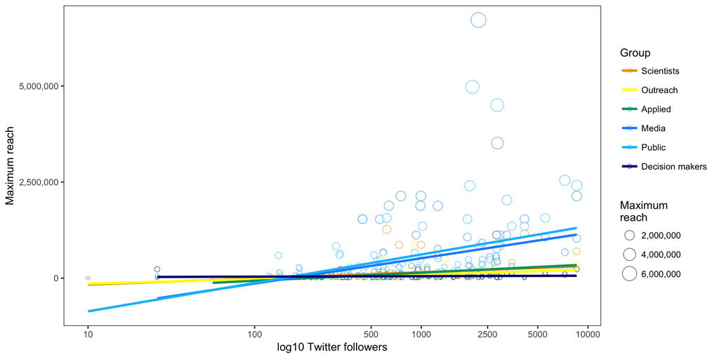